# ディジタル音声処理特論レポート

## 課題３「エレキギターのエフェクタの実装」

### 学籍番号：G23TX0XX， 氏名：○○ ○○

6.2節では音色を豊かにするために使われる技術であるエフェクタの原理の解説とプログラミングによる実装を行いました。楽器に詳しい人の場合，エフェクタと聞くとエレキギターを演奏する際に用いるデバイスのことを思い浮かべるかもしれません.本節ではエレキギター用の主要なエフェクタの原理とプログラミングによる簡易的な実装，そしてこれらのエフェクタによって音がどのように変化していくのかを見てみましょう。

### 6.x.1 オーバードライブ

オーバードライブとは，ロックに不可欠な歪んだ音を得るためのエフェクタです。今回は，音を歪ませるために双曲線関数 $\tanh$ を用います。

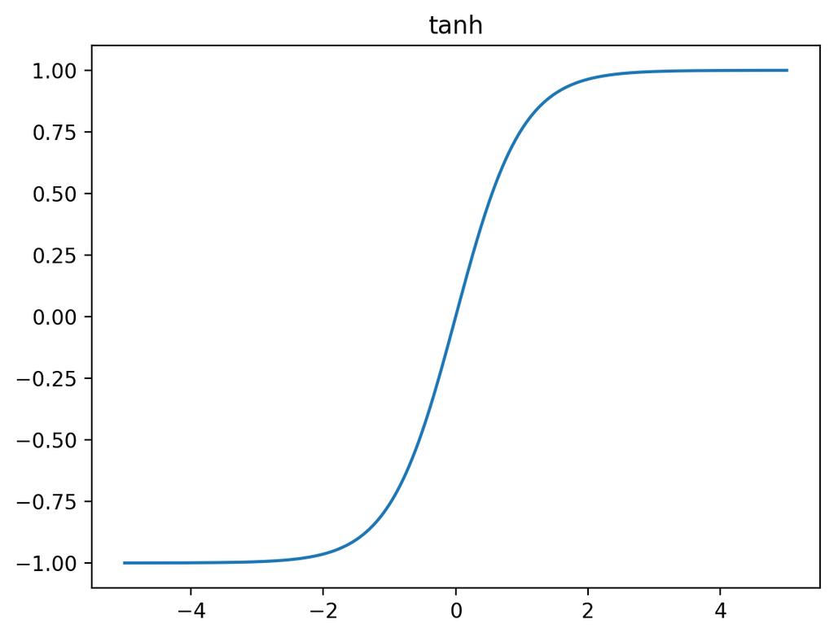

```python
x_values = np.linspace(-5, 5, 1000)
y_values = np.tanh(x_values)
plt.plot(x_values, y_values)
plt.title('tanh')
plt.show()
```

```
172296
```

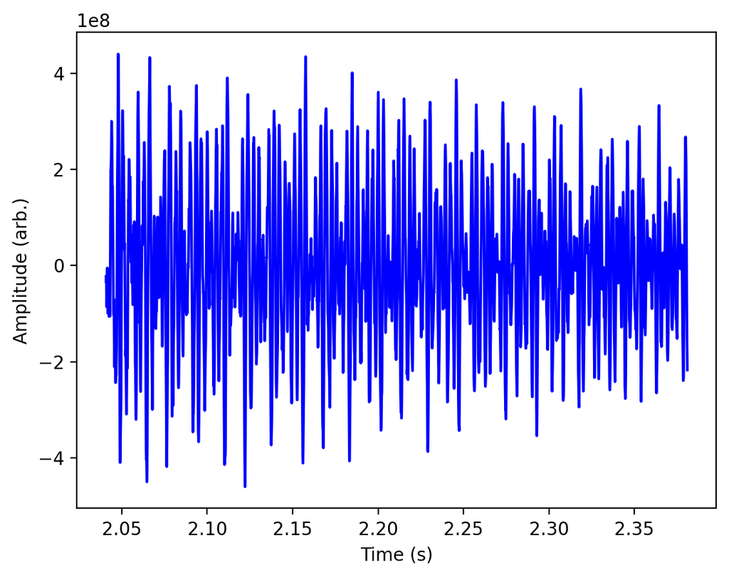

[interactive chart not shown]

```python
fs, wave_data = scipy.io.wavfile.read ('maou_se_inst_guitar08.wav')  # 音楽データを読み込みます。

sampling_interval = 1.0 / fs                  # サンプリング間隔は，サンプリング周波数の逆数
times = np.arange ( len ( wave_data )) * sampling_interval  # サンプル系列の時刻データの配列

print(len(wave_data))
start = 90000; end = start+15000     # 表示する区間の先頭と末尾を指定して，
plot_wave(times[start:end], wave_data[start:end]) # 波形を表示します。
Audio(wave_data, rate = fs)
```

それでは，オーバードライブを実装して音がどのように変化するか聞いてみましょう。（音量注意！）

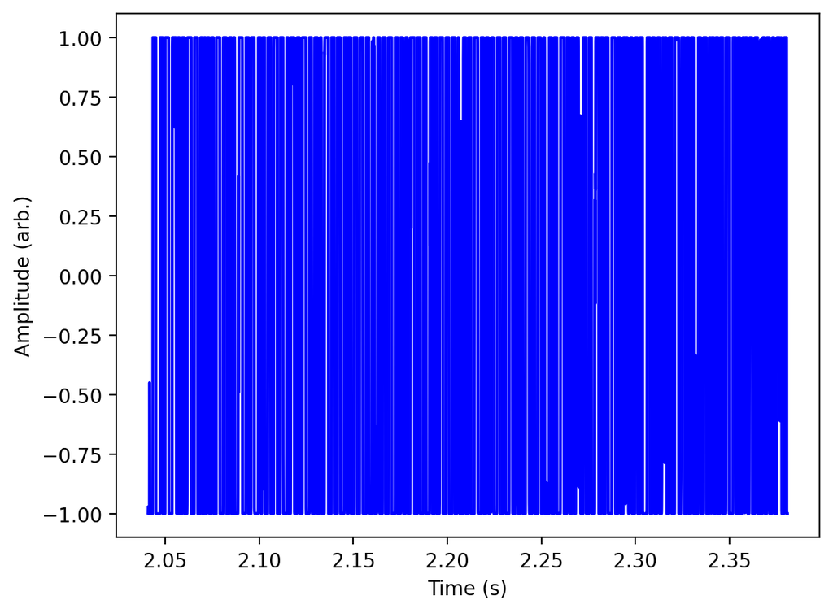

[interactive chart not shown]

```python
gain = 1.0*1e-7 # 歪みの強さ
overdrive_wave = np.tanh(gain * wave_data)

plot_wave(times[start:end], overdrive_wave[start:end])
Audio(overdrive_wave, rate = fs)
```

いわゆる「音が割れている」現象が起きました。波形も隙間がなく海苔みたいになっています（「海苔波形」と言われたりします）。もっと狭い区間を見て波形がどのようになっているか見てみましょう。

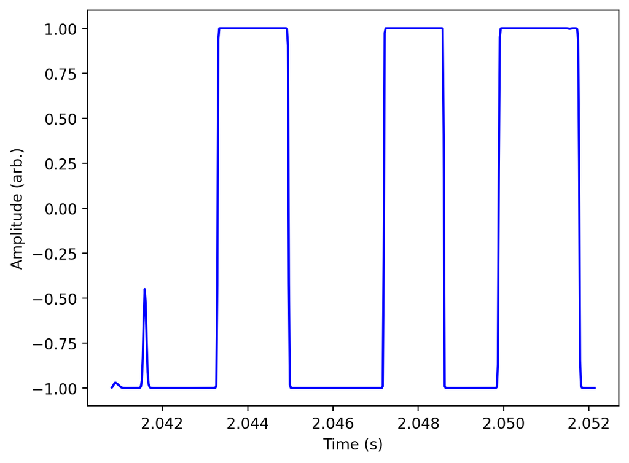

```python
plot_wave(times[start:start+500], overdrive_wave[start:start+500])  # 波形を表示します。
```

このとおり，ほとんどの時間点において瞬時振幅値が1もしくは-1になっていることがわかります。

### 6.x.2 コーラス

コーラスは，入力された音に対してピッチを少しずらして遅延させたものを重ねることによって揺らぎや厚みを加えるエフェクタです。まるで2本のギターが鳴っているかのような音になることから，英語で合唱を意味するその名前がついています。  
それでは，コーラスを実装して音がどのように変化するか聞いてみましょう。

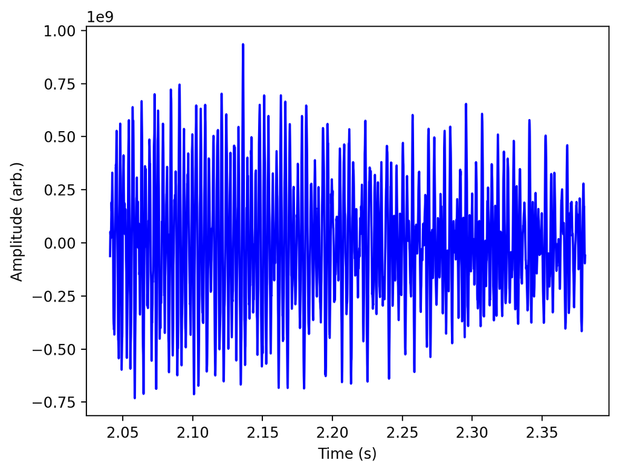

[interactive chart not shown]

```python
chorus_data = np.zeros_like(wave_data, dtype=np.float64)
depth = 1.5 # コーラス効果の深さ
rate = 0.2 # コーラスの振動の速さ
delay = 1500 # コーラスの遅延
for i in range(len(wave_data)):
  delay_sample = int(delay * np.sin(2 * np.pi * rate * i / len(wave_data)))
  chorus_data[i] = wave_data[i] + depth * wave_data[(i + delay_sample) % len(wave_data)]

plot_wave(times[start:end], chorus_data[start:end])
Audio(chorus_data, rate = fs)
```

波形には大きな変化は見られませんでしたが，柔らかく心地よいメロウな音色になりました。  
次はコーラスの振動をより速くしてみましょう。

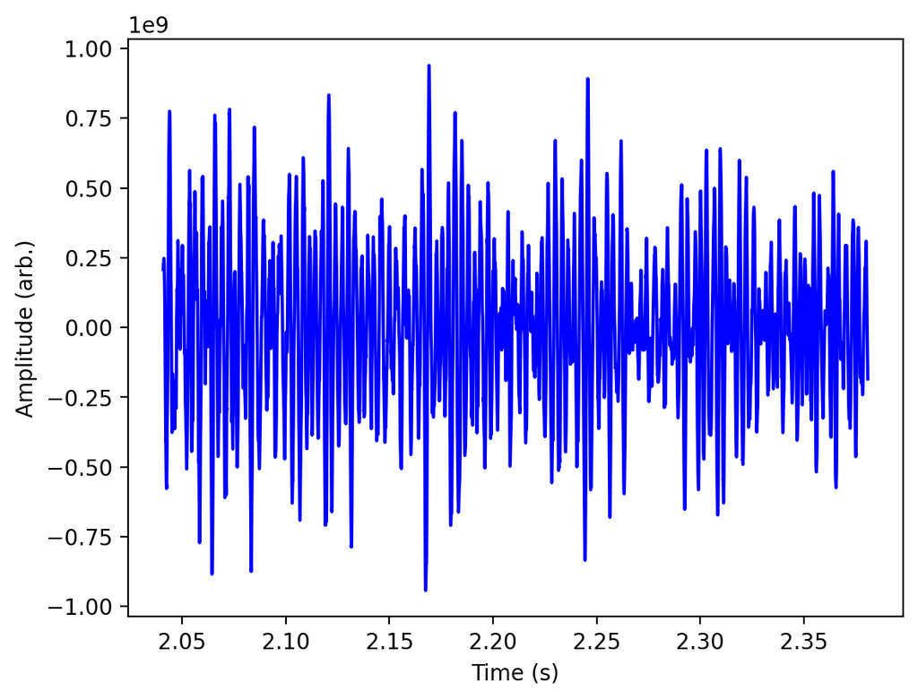

[interactive chart not shown]

```python
chorus_data = np.zeros_like(wave_data, dtype=np.float64)
depth = 1.5 # コーラス効果の深さ
rate = 1.0 # コーラスの振動の速さ
delay = 1500 # コーラスの遅延
for i in range(len(wave_data)):
  delay_sample = int(delay * np.sin(2 * np.pi * rate * i / len(wave_data)))
  chorus_data[i] = wave_data[i] + depth * wave_data[(i + delay_sample) % len(wave_data)]

plot_wave(times[start:end], chorus_data[start:end])
Audio(chorus_data, rate = fs)
```

重なる音のピッチの揺らぎが大きくなったことにより，不協和音が発生しました。

### 6.x.3 ワウ

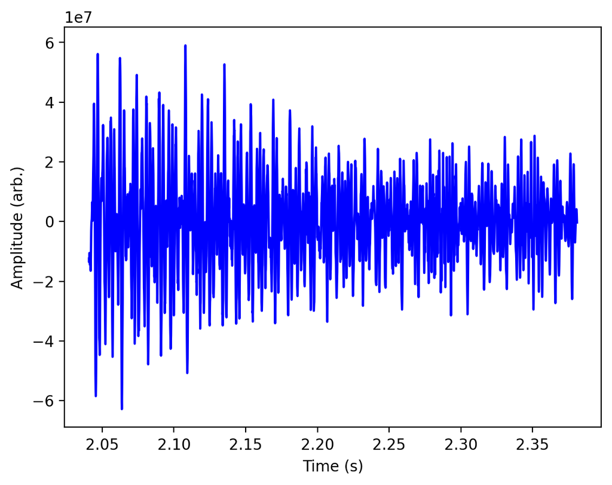

[interactive chart not shown]

```python
wahwah_data = np.zeros_like(wave_data)
rate = 2
depth = 3.5
speed = (2.0 * np.pi * rate) / fs
freq = 800

theta = 0
for i in range(len(wave_data)):
  theta += speed
  a = (np.cos(theta) * 0.5) + 0.5
  tmp_freq = freq * (1.0 + a * depth)
  # IIRフィルタを用いたローパスフィルタ
  alpha = (2 * np.pi * tmp_freq) / fs
  b = (1 - np.cos(alpha)) / 2
  a0 = 1 + b
  a1 = -2 * np.cos(alpha)
  a2 = 1 - b

  wahwah_data[i] = b * (wave_data[i] + 2 * wave_data[i - 1] + wave_data[i - 2]) - a1 * wahwah_data[i - 1] - a2 * wahwah_data[i - 2]

wahwah_data = wahwah_data[60000:]

plot_wave(times[start:end], wahwah_data[start:end])
Audio(wahwah_data, rate = fs)
```

本当にワウ，ワウ，といった感じに聞こえますね。次に，ワウをかける周期を短くしてみましょう。

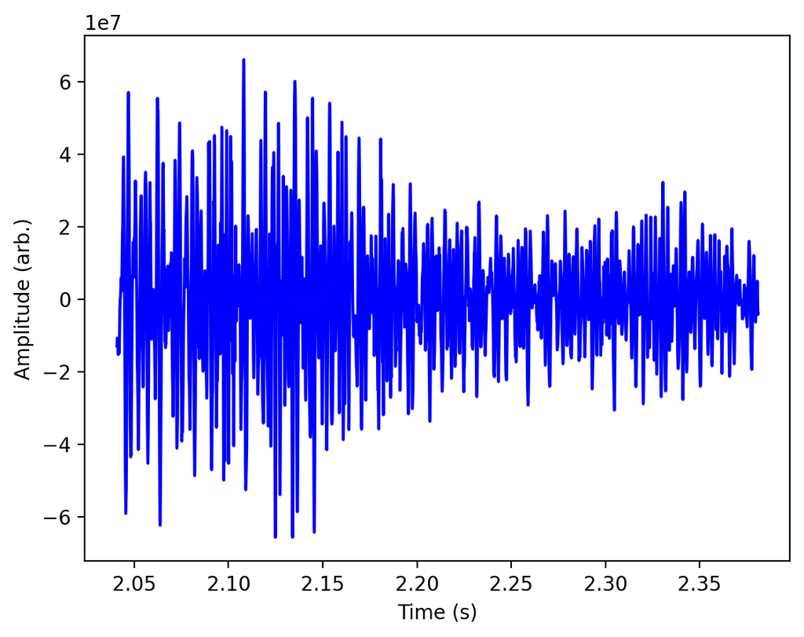

[interactive chart not shown]

```python
wahwah_data = np.zeros_like(wave_data)
rate = 5
depth = 3.5
speed = (2.0 * np.pi * rate) / fs
freq = 800

theta = 0
for i in range(len(wave_data)):
  theta += speed
  a = (np.cos(theta) * 0.5) + 0.5
  tmp_freq = freq * (1.0 + a * depth)
  # IIRフィルタを用いたローパスフィルタ
  alpha = (2 * np.pi * tmp_freq) / fs
  b = (1 - np.cos(alpha)) / 2
  a0 = 1 + b
  a1 = -2 * np.cos(alpha)
  a2 = 1 - b

  wahwah_data[i] = b * (wave_data[i] + 2 * wave_data[i - 1] + wave_data[i - 2]) - a1 * wahwah_data[i - 1] - a2 * wahwah_data[i - 2]

wahwah_data = wahwah_data[60000:]

plot_wave(times[start:end], wahwah_data[start:end])
Audio(wahwah_data, rate = fs)
```

より細かくワウを掛けることができました。  
エレキギターには他にもたくさんの豊富なエフェクタがあります。興味がある方は他のエフェクタもプログラミングで実装してみてはいかがでしょうか。

参考文献  
[1] 【今さら聞けない】エフェクターの基礎知識編 ～エフェクターの種類と効果～ https://guitarsele.com/article/feature/basic-knowledge-of-effector-speicies/  
[2] C++でVST作り https://www.utsbox.com/?cat=19

使用した音源  
魔王魂 ギター08 https://maou.audio/?s=%E3%82%AE%E3%82%BF%E3%83%BC#google_vignette